# FDA FINAL PROJECT

## DATA VISUALISATION

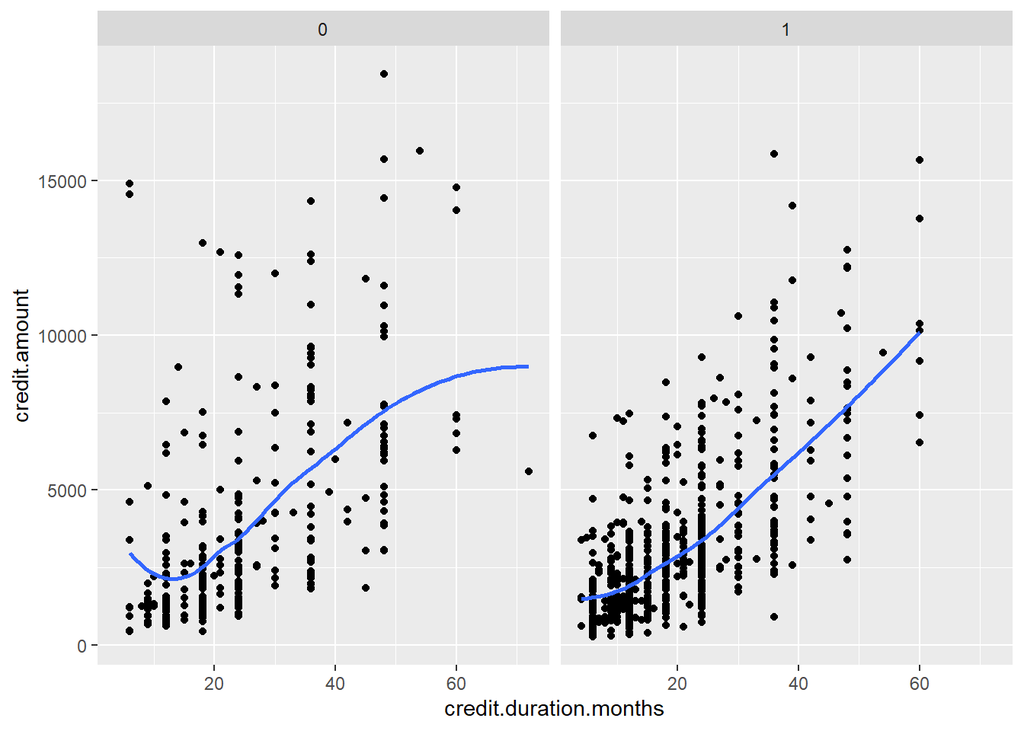

```r
library(ggplot2)
g <- ggplot(credit.df,aes(x=credit.duration.months,y=credit.amount))
g+geom_point()+geom_smooth(se=FALSE)+
  facet_grid(. ~ credit.rating)
```

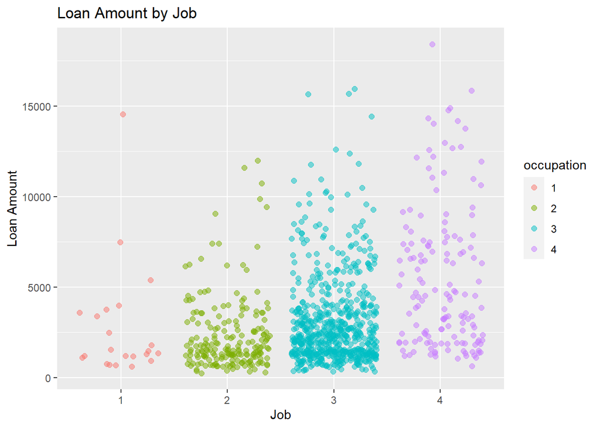

```r
g <- ggplot(credit.df,aes(x=occupation,y=credit.amount,color=occupation))
g+geom_jitter(size=2,alpha=0.5)+
  labs(title ="Loan Amount by Job", x = "Job", y = "Loan Amount")
```

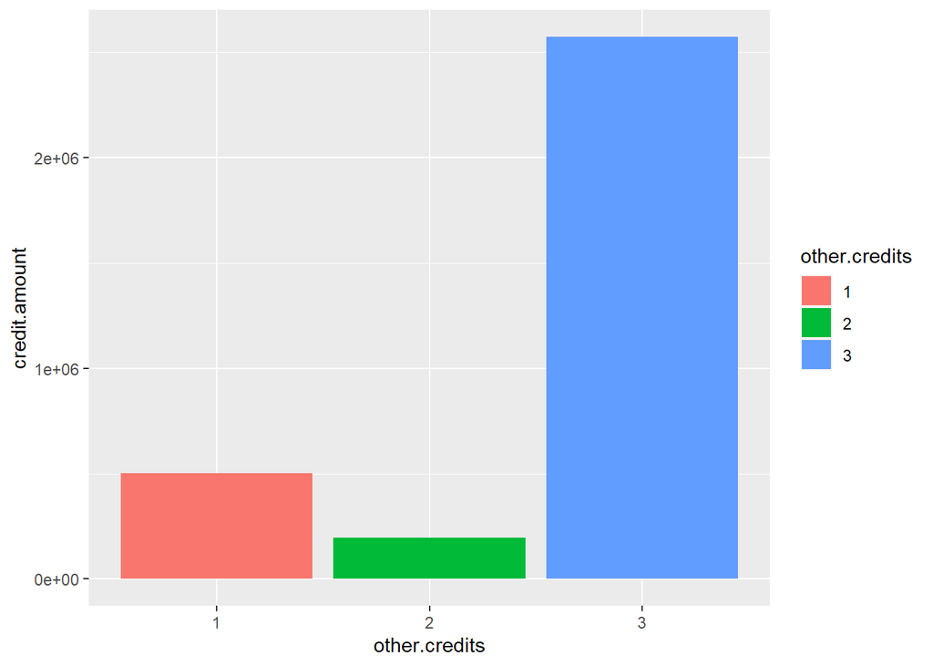

```r
p <- ggplot(data=credit.df, aes(x=other.credits, y=credit.amount, fill=other.credits )) +
  geom_bar(stat="identity")
p
```

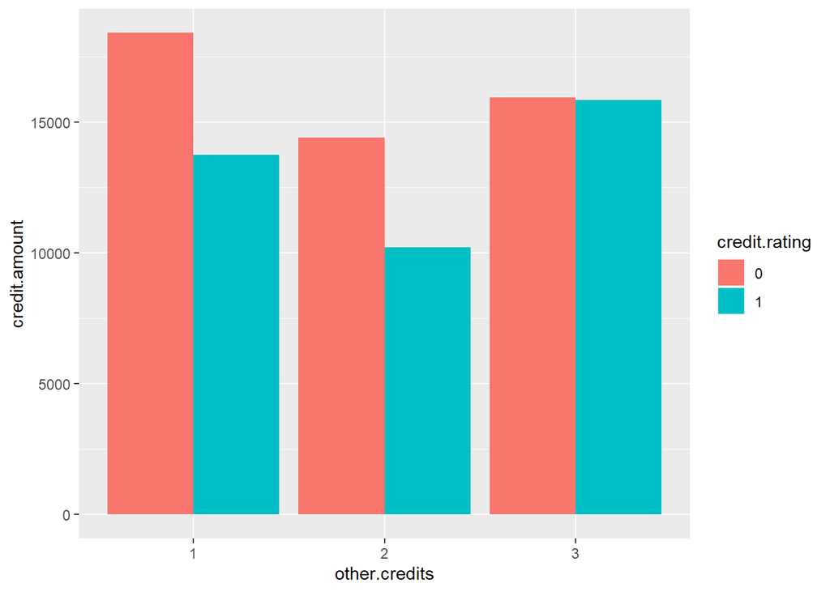

```r
p <- ggplot(data=credit.df, aes(x=other.credits, y=credit.amount, fill=credit.rating )) +
  geom_bar(stat="identity",position=position_dodge())
p
```

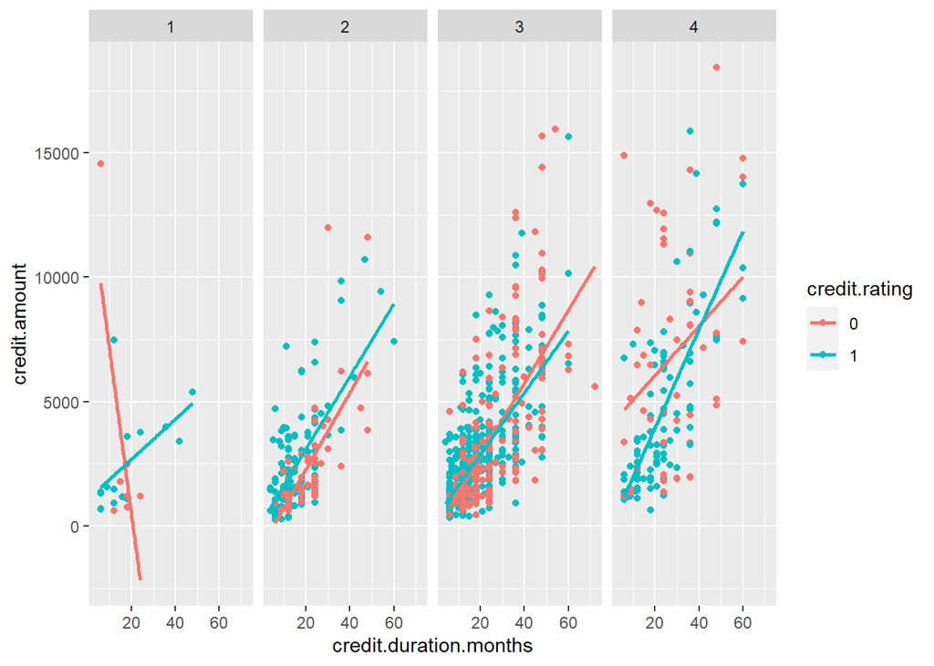

```r
g <- ggplot(credit.df,aes(x=credit.duration.months,y=credit.amount, color=credit.rating))
g+geom_point()+geom_smooth(se=FALSE,method='lm')+
  facet_grid(. ~ occupation)
```

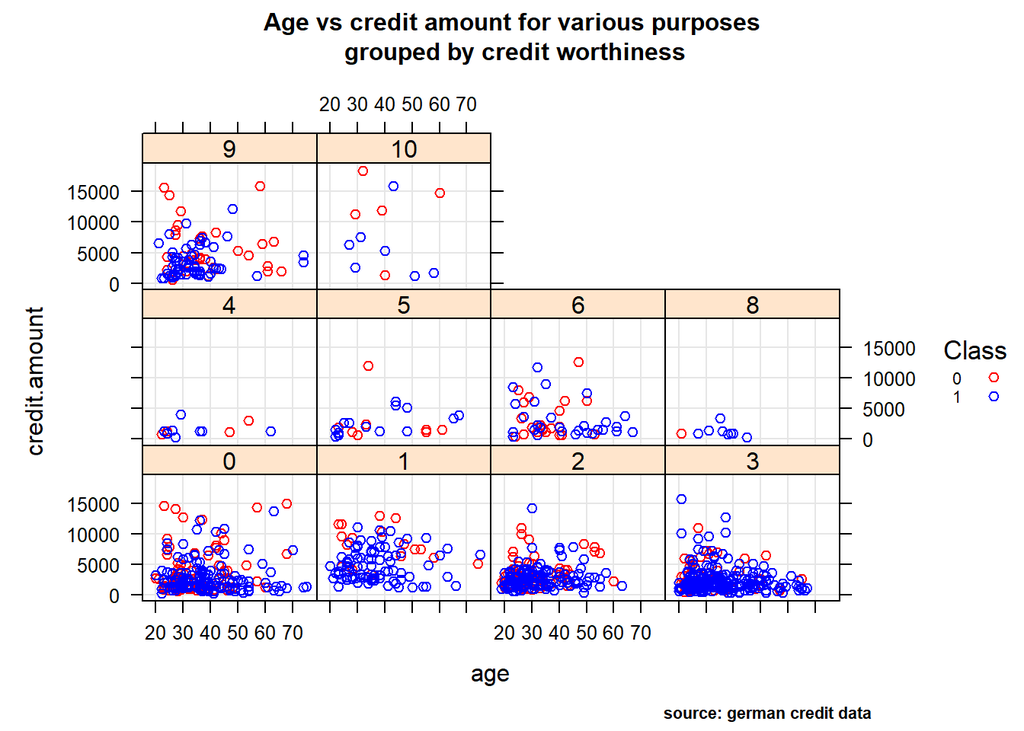

```r
library(lattice)
mycol <- c("red","blue")

xyplot(credit.amount ~ age|credit.purpose, credit.df,
       grid = TRUE,
       group= credit.rating,
       auto.key = list(points = TRUE, rectangles = FALSE, title="Class",cex=0.7, space = "right"),
       main=list(
         label="Age vs credit amount for various purposes\n grouped by credit worthiness",
         cex=1),
       sub= "source: german credit data",
       par.settings = c(simpleTheme(col = mycol),list(par.sub.text = list(cex = 0.7, col = "black",x=0.75))))
```

### Data analysis and transformation

```r
attach(credit.df)
library(gridExtra)
library(ggplot2)

get.numeric.variable.stats <- function(indep.var, detailed=FALSE){
  options(scipen=100)
  options(digits=2)
  if (detailed){
    var.stats <- stat.desc(indep.var)
  }else{
    var.stats <- summary(indep.var)
  }

  df <- data.frame(round(as.numeric(var.stats),2))
  colnames(df) <- deparse(substitute(indep.var))
  rownames(df) <- names(var.stats)

  #if (names(dev.cur()) != "null device"){
    #dev.off()
  #}
  grid.table(t(df))
}

# visualizations
# histograms\density
visualize.distribution <- function(indep.var){
  pl1 <- qplot(indep.var, geom="histogram",
               fill=I('gray'), binwidth=5,
               col=I('black'))+ theme_bw()
  pl2 <- qplot(indep.var, geom="density",
               fill=I('gray'), binwidth=5,
               col=I('black'))+ theme_bw()

  grid.arrange(pl1,pl2, ncol=2)
}

# box plots
visualize.boxplot <- function(indep.var, dep.var){
  pl1 <- qplot(factor(0),indep.var, geom="boxplot",
               xlab = deparse(substitute(indep.var)),
               ylab="values") + theme_bw()
  pl2 <- qplot(dep.var,indep.var,geom="boxplot",
               xlab = deparse(substitute(dep.var)),
               ylab = deparse(substitute(indep.var))) + theme_bw()

  grid.arrange(pl1,pl2, ncol=2)
}

# analyze categorical variables
# summary statistics
get.categorical.variable.stats <- function(indep.var){

  feature.name = deparse(substitute(indep.var))
  df1 <- data.frame(table(indep.var))
  colnames(df1) <- c(feature.name, "Frequency")
  df2 <- data.frame(prop.table(table(indep.var)))
  colnames(df2) <- c(feature.name, "Proportion")

  df <- merge(
    df1, df2, by = feature.name
  )
  ndf <- df[order(-df$Frequency),]
  #if (names(dev.cur()) != "null device"){
   # dev.off()
  #}
  grid.table(ndf)
}

# generate contingency table
get.contingency.table <- function(dep.var, indep.var,
                                  stat.tests=F){
  if(stat.tests == F){
    CrossTable(dep.var, indep.var, digits=1,
               prop.r=F, prop.t=F, prop.chisq=F)
  }else{
    CrossTable(dep.var, indep.var, digits=1,
               prop.r=F, prop.t=F, prop.chisq=F,
               chisq=T, fisher=T)
  }
}
```

```r
# visualizations
# barcharts
visualize.barchart <- function(indep.var){
  qplot(indep.var, geom="bar",
        fill=I('gray'), col=I('black'),
        xlab = deparse(substitute(indep.var))) + theme_bw()
}


# mosaic plots
visualize.contingency.table <- function(dep.var, indep.var){
  if (names(dev.cur()) != "null device"){
    dev.off()
  }
  mosaicplot(dep.var ~ indep.var, color=T,
             main = "Contingency table plot")
}
```

```r
attach(credit.df)
```

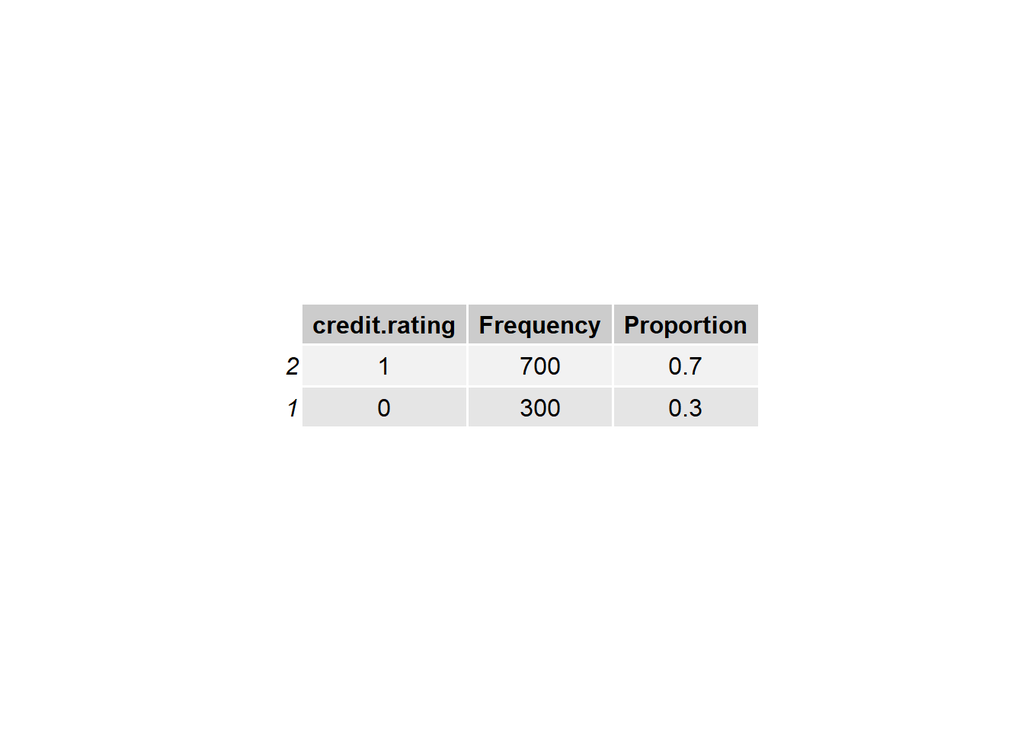

```r
library(gridExtra)
library(ggplot2)

visualize.barchart <- function(indep.var){
  qplot(indep.var, geom="bar",
        fill=I('gray'), col=I('black'),
        xlab = deparse(substitute(indep.var))) + theme_bw()
}


get.categorical.variable.stats(credit.rating)
```

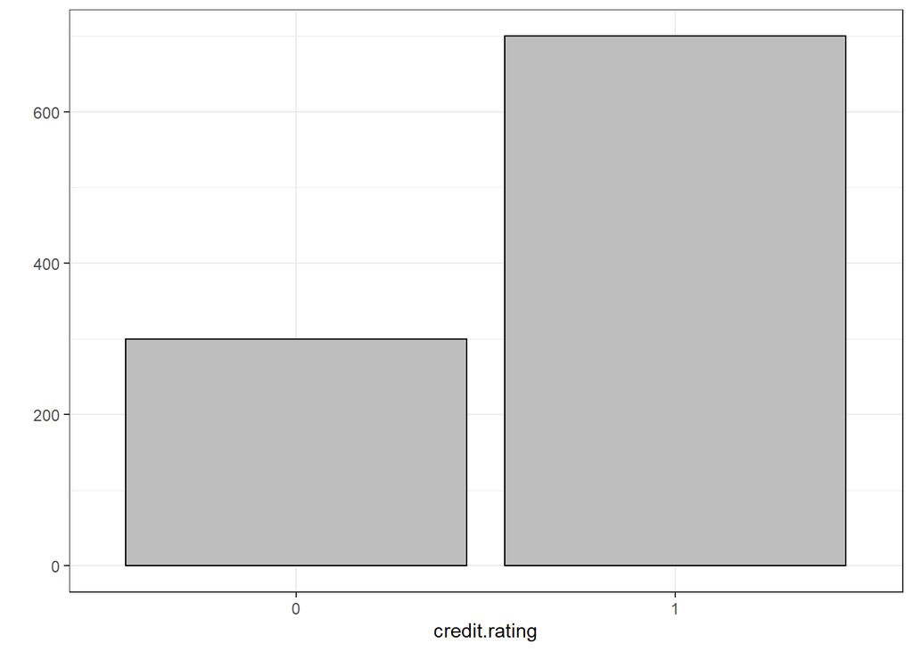

```r
visualize.barchart(credit.rating)
```

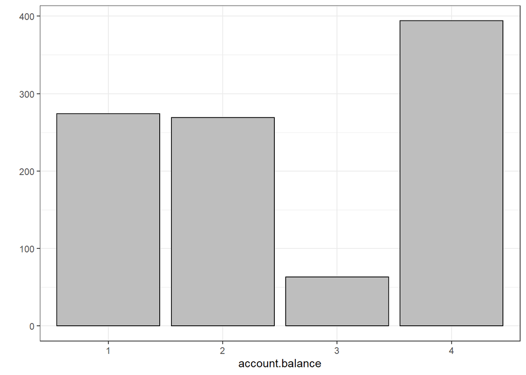

```r
visualize.barchart(account.balance)
```

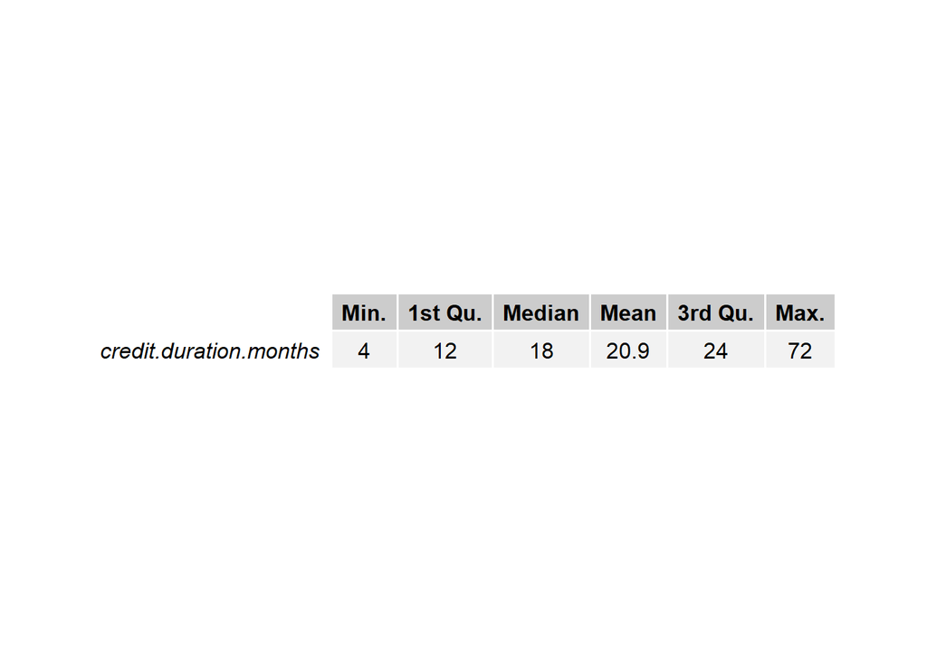

```r
get.numeric.variable.stats(credit.duration.months)
```

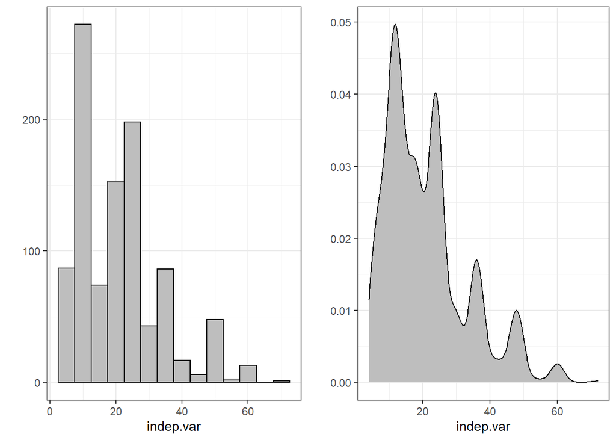

```r
visualize.distribution(credit.duration.months)
```

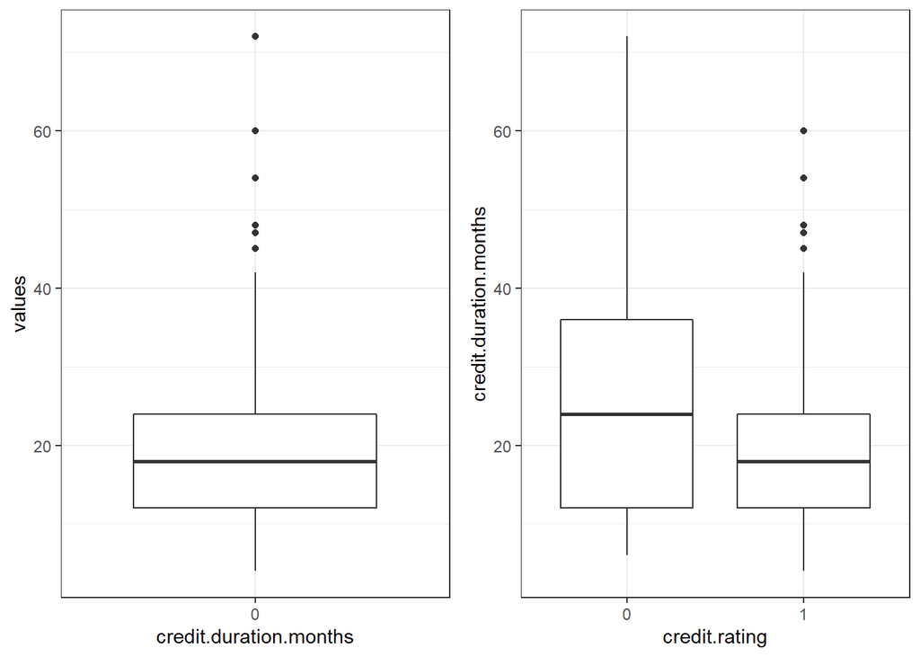

```r
visualize.boxplot(credit.duration.months,credit.rating)
```

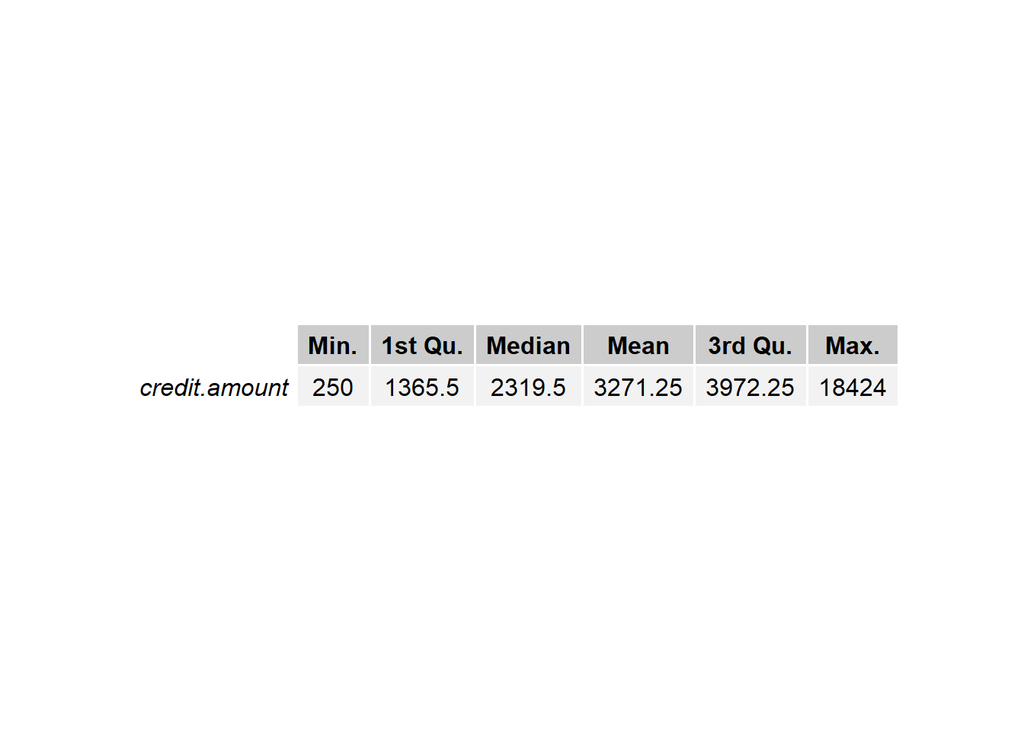

```r
library(car)
library(gmodels)

get.numeric.variable.stats(credit.amount)
```

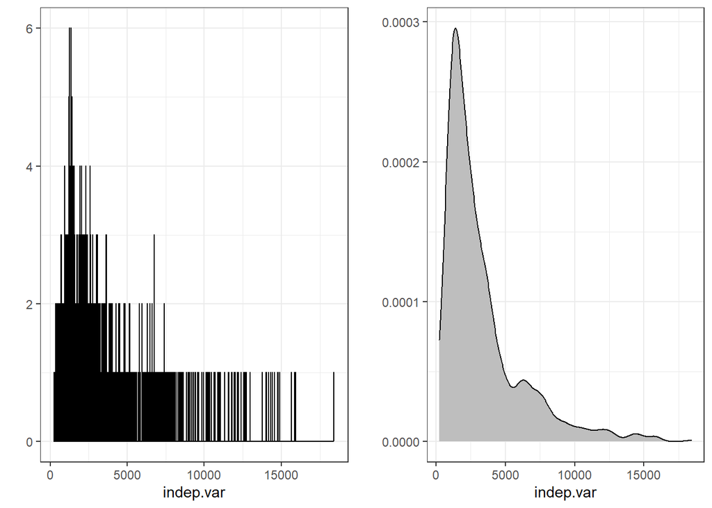

```r
visualize.distribution(credit.amount)
```

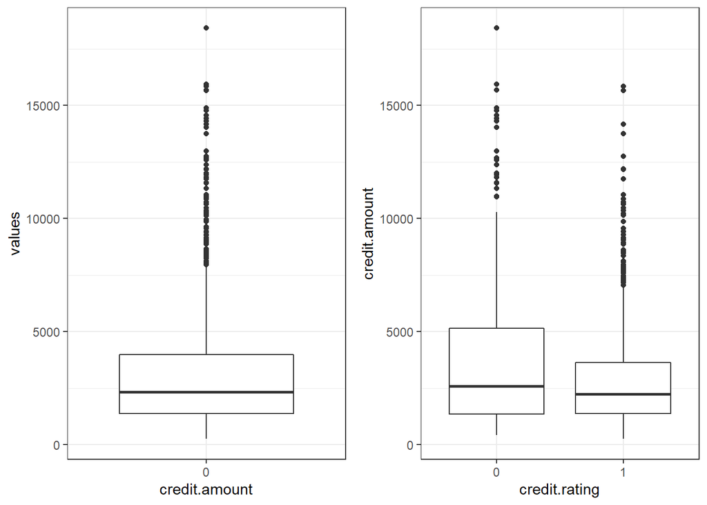

```r
visualize.boxplot(credit.amount,credit.rating)
```

```r
get.contingency.table(credit.rating,installment.rate,stat.tests = TRUE)
```

```
##
##
##    Cell Contents
## |-------------------------|
## |                       N |
## |           N / Col Total |
## |-------------------------|
##
##
## Total Observations in Table:  1000
##
##
##              | indep.var
##      dep.var |         1 |         2 |         3 |         4 | Row Total |
## -------------|-----------|-----------|-----------|-----------|-----------|
##            0 |        34 |        62 |        45 |       159 |       300 |
##              |       0.2 |       0.3 |       0.3 |       0.3 |           |
## -------------|-----------|-----------|-----------|-----------|-----------|
##            1 |       102 |       169 |       112 |       317 |       700 |
##              |       0.8 |       0.7 |       0.7 |       0.7 |           |
## -------------|-----------|-----------|-----------|-----------|-----------|
## Column Total |       136 |       231 |       157 |       476 |      1000 |
##              |       0.1 |       0.2 |       0.2 |       0.5 |           |
## -------------|-----------|-----------|-----------|-----------|-----------|
##
##
## Statistics for All Table Factors
##
##
## Pearson's Chi-squared test
## ------------------------------------------------------------
## Chi^2 =  5.5     d.f. =  3     p =  0.14
##
##
##
## Fisher's Exact Test for Count Data
## ------------------------------------------------------------
## Alternative hypothesis: two.sided
## p =  0.15
##
##
```

## Checking significance of different variables

```r
# perform statistical tests for residence.duration
fisher.test(credit.rating, residence.duration)
```

```
##
##  Fisher's Exact Test for Count Data
##
## data:  credit.rating and residence.duration
## p-value = 0.9
## alternative hypothesis: two.sided
```

```r
chisq.test(credit.rating, residence.duration)
```

```
##
##  Pearson's Chi-squared test
##
## data:  credit.rating and residence.duration
## X-squared = 0.7, df = 3, p-value = 0.9
```

```r
# perform statistical tests for current.assets
fisher.test(credit.rating, current.assets)
```

```
##
##  Fisher's Exact Test for Count Data
##
## data:  credit.rating and current.assets
## p-value = 0.00003
## alternative hypothesis: two.sided
```

```r
chisq.test(credit.rating, current.assets)
```

```
##
##  Pearson's Chi-squared test
##
## data:  credit.rating and current.assets
## X-squared = 24, df = 3, p-value = 0.00003
```

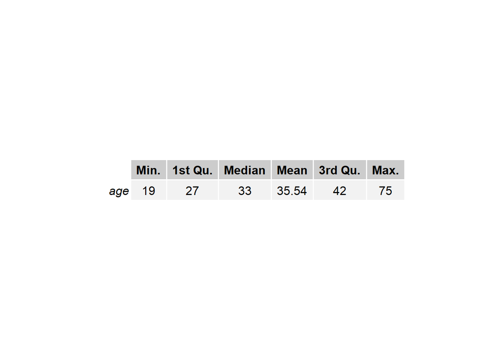

```r
get.numeric.variable.stats(age)
```

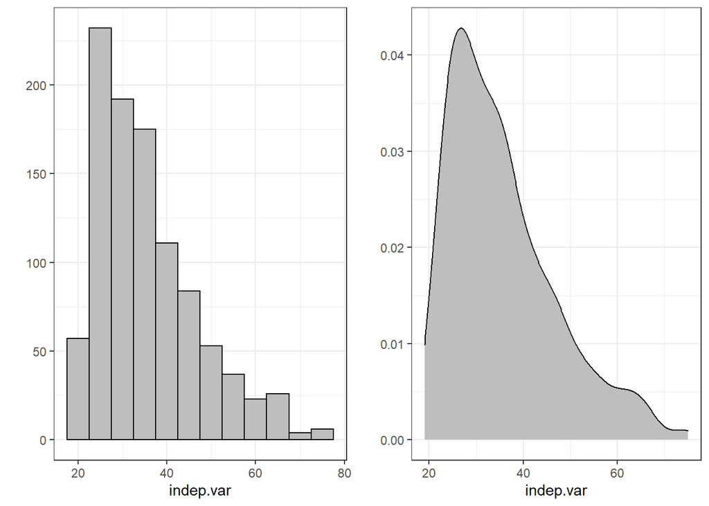

```r
visualize.distribution(age)
```

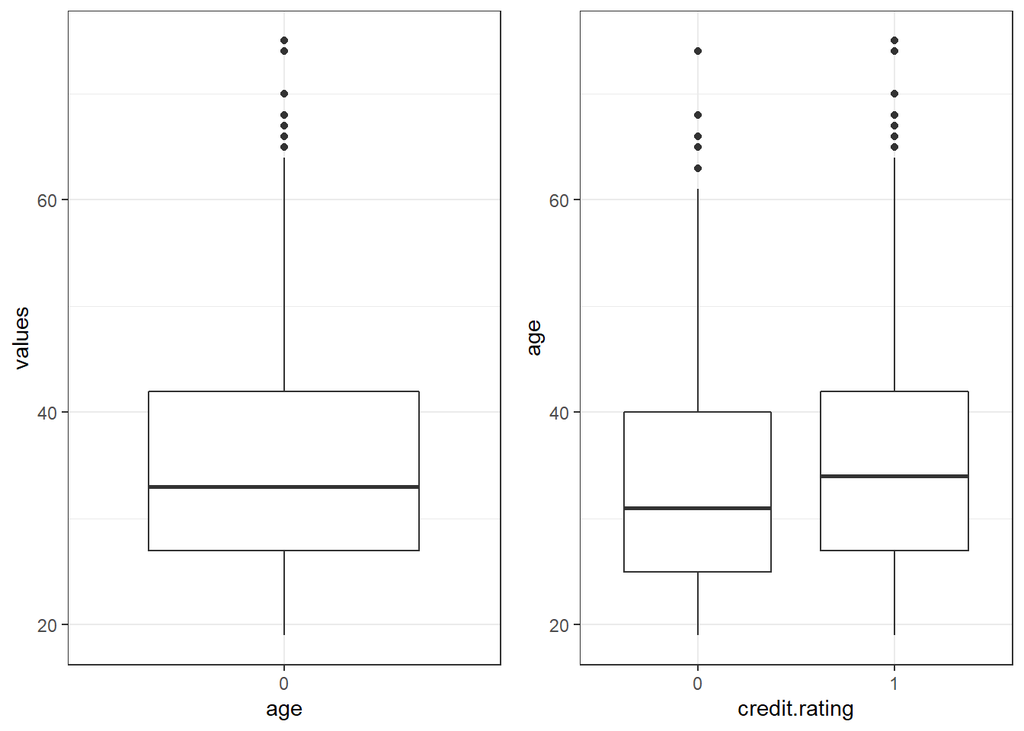

```r
visualize.boxplot(age,credit.rating)
```

```r
# perform statistical tests for apartment.type
fisher.test(credit.rating, apartment.type)
```

```
##
##  Fisher's Exact Test for Count Data
##
## data:  credit.rating and apartment.type
## p-value = 0.0001
## alternative hypothesis: two.sided
```

```r
chisq.test(credit.rating, apartment.type)
```

```
##
##  Pearson's Chi-squared test
##
## data:  credit.rating and apartment.type
## X-squared = 19, df = 2, p-value = 0.00009
```

```r
# perform statistical tests for occupation
fisher.test(credit.rating, occupation)
```

```
##
##  Fisher's Exact Test for Count Data
##
## data:  credit.rating and occupation
## p-value = 0.6
## alternative hypothesis: two.sided
```

```r
chisq.test(credit.rating, occupation)
```

```
##
##  Pearson's Chi-squared test
##
## data:  credit.rating and occupation
## X-squared = 2, df = 3, p-value = 0.6
```

```r
# perform statistical tests for dependents
fisher.test(credit.rating, dependents)
```

```
##
##  Fisher's Exact Test for Count Data
##
## data:  credit.rating and dependents
## p-value = 1
## alternative hypothesis: true odds ratio is not equal to 1
## 95 percent confidence interval:
##  0.69 1.52
## sample estimates:
## odds ratio
##          1
```

```r
chisq.test(credit.rating, dependents)
```

```
##
##  Pearson's Chi-squared test with Yates' continuity correction
##
## data:  credit.rating and dependents
## X-squared = 0, df = 1, p-value = 1
```

```r
# perform statistical tests for telephone
fisher.test(credit.rating, telephone)
```

```
##
##  Fisher's Exact Test for Count Data
##
## data:  credit.rating and telephone
## p-value = 0.3
## alternative hypothesis: true odds ratio is not equal to 1
## 95 percent confidence interval:
##  0.88 1.57
## sample estimates:
## odds ratio
##        1.2
```

```r
chisq.test(credit.rating, telephone)
```

```
##
##  Pearson's Chi-squared test with Yates' continuity correction
##
## data:  credit.rating and telephone
## X-squared = 1, df = 1, p-value = 0.3
```

```r
# perform statistical tests for foreign.worker
fisher.test(credit.rating, foreign.worker)
```

```
##
##  Fisher's Exact Test for Count Data
##
## data:  credit.rating and foreign.worker
## p-value = 0.009
## alternative hypothesis: true odds ratio is not equal to 1
## 95 percent confidence interval:
##   1.3 14.3
## sample estimates:
## odds ratio
##        3.7
```

```r
chisq.test(credit.rating, foreign.worker)
```

```
##
##  Pearson's Chi-squared test with Yates' continuity correction
##
## data:  credit.rating and foreign.worker
## X-squared = 6, df = 1, p-value = 0.02
```

```r
credit.df<-read.csv("credit_dataset_final.csv", header=TRUE, sep=",")
table(credit.df$credit.rating)
```

```
##
##   0   1
## 300 700
```

```r
## data type transformations - factoring
to.factors <- function(df, variables){
  for (variable in variables){
    df[[variable]] <- as.factor(df[[variable]])
  }
  return(df)
}

## normalizing - scaling
scale.features <- function(df, variables){
  for (variable in variables){
    df[[variable]] <- scale(df[[variable]], center=T, scale=T)
  }
  return(df)
}

numeric.vars<- c("credit.duration.months","age","credit.amount")

credit.df<- scale.features(credit.df,numeric.vars)

# factor variables
categorical.vars <- c('credit.rating', 'account.balance',
                      'previous.credit.payment.status',
                      'credit.purpose', 'savings',
                      'employment.duration', 'installment.rate',
                      'marital.status', 'guarantor',
                      'residence.duration', 'current.assets',
                      'other.credits', 'apartment.type',
                      'bank.credits', 'occupation',
                      'dependents', 'telephone', 'foreign.worker')

credit.df<- to.factors(df=credit.df,variables = categorical.vars)
```

## DATA PARTITIONS

#### Stratified random sampling is a method of sampling that involves the division of a population into smaller groups known as strata. This is useful for imbalanced datasets, and can be used to give more weight to a minority class. In stratified random sampling, the strata are formed based on members’ shared attributes or characteristics.

#### In our case we will use Good/Bad as strata and partition data into 70%-30% as train and test sets. The caret function createDataPartition() can be used to create balanced splits of the data

```r
library(kableExtra)
library(caret)
index <- createDataPartition(y = credit.df$credit.rating, p = 0.7, list = F)

# i create a function to calculate percent distribution for factors
pct <- function(x){
  tbl <- table(x)
  tbl_pct <- cbind(tbl,round(prop.table(tbl)*100,2))
  colnames(tbl_pct) <- c('Count','Percentage')
  kable(tbl_pct)
}
#training set and test set
train <- credit.df[index,]
pct(train$credit.rating)
```

|  | Count | Percentage |
| --- | --- | --- |
| 0 | 210 | 30 |
| 1 | 490 | 70 |

```r
table(train$credit.rating)
```

```
##
##   0   1
## 210 490
```

```r
test.data<- credit.df[-index,]
```

## FEATURE SELECTION FUNCTION

```r
library(caret)
library(randomForest)
run.feature.selection <- function(num.iters=20, feature.vars, class.var){
  set.seed(10)
  variable.sizes <- 1:10
  control <- rfeControl(functions = rfFuncs, method = "cv",
                        verbose = FALSE, returnResamp = "all",
                        number = num.iters)
  results.rfe <- rfe(x = feature.vars, y = class.var,
                     sizes = variable.sizes,
                     rfeControl = control)
  return(results.rfe)
}

rfe.results <- run.feature.selection(feature.vars=train[,-1],
                                     class.var=train[,1])

rfe.results
```

```
##
## Recursive feature selection
##
## Outer resampling method: Cross-Validated (20 fold)
##
## Resampling performance over subset size:
##
##  Variables Accuracy Kappa AccuracySD KappaSD Selected
##          1    0.674 0.126     0.0490   0.137
##          2    0.716 0.183     0.0440   0.123
##          3    0.740 0.263     0.0319   0.120
##          4    0.730 0.296     0.0577   0.175
##          5    0.742 0.330     0.0561   0.158
##          6    0.760 0.383     0.0684   0.191
##          7    0.760 0.375     0.0556   0.167
##          8    0.763 0.369     0.0453   0.141        *
##          9    0.761 0.378     0.0500   0.126
##         10    0.754 0.341     0.0518   0.158
##         20    0.753 0.329     0.0423   0.144
##
## The top 5 variables (out of 8):
##    account.balance, previous.credit.payment.status, credit.duration.months, savings, credit.amount
```

```r
varImp(rfe.results)
```

```
##                                Overall
## account.balance                   22.5
## previous.credit.payment.status    10.0
## credit.duration.months             9.1
## savings                            6.6
## credit.amount                      6.5
## guarantor                          4.6
## employment.duration                3.6
## installment.rate                   3.6
## occupation                         3.6
## telephone                          3.5
## age                                3.4
## apartment.type                     3.3
## current.assets                     3.3
## bank.credits                       3.0
```

## PREDICTIVE MODELS

### LOGESTIC REGRESSION

```r
library(caret)
library(ROCR)

source("performance_plot_utils.R")

test.feature.vars<-test.data[,-1]
test.class.var<- test.data[,1]

formula.init<- "credit.rating ~ ."
formula.init<- as.formula(formula.init)

lr.model<- glm(formula = formula.init,data = train,
               family = "binomial")

# view model details
summary(lr.model)
```

```
##
## Call:
## glm(formula = formula.init, family = "binomial", data = train)
##
## Deviance Residuals:
##    Min      1Q  Median      3Q     Max
## -2.484  -0.703   0.384   0.715   2.198
##
## Coefficients:
##                                 Estimate Std. Error z value     Pr(>|z|)
## (Intercept)                      -0.3380     0.9585   -0.35       0.7244
## account.balance2                  0.5766     0.2567    2.25       0.0247 *
## account.balance3                  1.6914     0.2658    6.36 0.0000000002 ***
## credit.duration.months           -0.2390     0.1291   -1.85       0.0642 .
## previous.credit.payment.status2   0.6885     0.3782    1.82       0.0687 .
## previous.credit.payment.status3   1.6065     0.4105    3.91 0.0000908760 ***
## credit.purpose2                  -0.5888     0.4621   -1.27       0.2026
## credit.purpose3                  -0.6685     0.4382   -1.53       0.1271
## credit.purpose4                  -1.0542     0.4163   -2.53       0.0113 *
## credit.amount                    -0.4720     0.1457   -3.24       0.0012 **
## savings2                          0.2060     0.3311    0.62       0.5339
## savings3                          1.1008     0.4355    2.53       0.0115 *
## savings4                          0.8000     0.3023    2.65       0.0081 **
## employment.duration2              0.2472     0.2877    0.86       0.3902
## employment.duration3              0.8992     0.3492    2.58       0.0100 *
## employment.duration4              0.2627     0.3263    0.81       0.4207
## installment.rate2                -0.2725     0.3713   -0.73       0.4631
## installment.rate3                -0.7080     0.4016   -1.76       0.0779 .
## installment.rate4                -1.0227     0.3549   -2.88       0.0040 **
## marital.status3                   0.5368     0.2360    2.27       0.0230 *
## marital.status4                   0.1269     0.3682    0.34       0.7303
## guarantor2                        0.5587     0.3331    1.68       0.0935 .
## residence.duration2              -0.0824     0.3421   -0.24       0.8096
## residence.duration3               0.1874     0.3877    0.48       0.6289
## residence.duration4               0.2497     0.3422    0.73       0.4656
## current.assets2                  -0.4054     0.3066   -1.32       0.1860
## current.assets3                  -0.4801     0.2856   -1.68       0.0928 .
## current.assets4                  -0.8198     0.5118   -1.60       0.1092
## age                               0.0652     0.1248    0.52       0.6017
## other.credits2                    0.0996     0.2736    0.36       0.7159
## apartment.type2                   0.7345     0.2813    2.61       0.0090 **
## apartment.type3                   0.8029     0.5686    1.41       0.1579
## bank.credits2                    -0.5094     0.2912   -1.75       0.0802 .
## occupation2                      -0.4635     0.7854   -0.59       0.5551
## occupation3                      -0.2685     0.7601   -0.35       0.7239
## occupation4                      -0.0857     0.7905   -0.11       0.9137
## dependents2                      -0.3871     0.2945   -1.31       0.1887
## telephone2                        0.3617     0.2364    1.53       0.1259
## foreign.worker2                   0.9421     0.7209    1.31       0.1912
## ---
## Signif. codes:  0 '***' 0.001 '**' 0.01 '*' 0.05 '.' 0.1 ' ' 1
##
## (Dispersion parameter for binomial family taken to be 1)
##
##     Null deviance: 855.21  on 699  degrees of freedom
## Residual deviance: 631.86  on 661  degrees of freedom
## AIC: 709.9
##
## Number of Fisher Scoring iterations: 5
```

```r
lr.predictions<- predict(lr.model,test.data, type="response")

lr.predictions<- round(lr.predictions)

u=union(lr.predictions,test.class.var)

confusionMatrix(table(factor(lr.predictions,u),factor(test.class.var,u)))
```

```
## Confusion Matrix and Statistics
##
##
##       1   0
##   1 186  49
##   0  24  41
##
##                Accuracy : 0.757
##                  95% CI : (0.704, 0.804)
##     No Information Rate : 0.7
##     P-Value [Acc > NIR] : 0.01741
##
##                   Kappa : 0.371
##
##  Mcnemar's Test P-Value : 0.00497
##
##             Sensitivity : 0.886
##             Specificity : 0.456
##          Pos Pred Value : 0.791
##          Neg Pred Value : 0.631
##              Prevalence : 0.700
##          Detection Rate : 0.620
##    Detection Prevalence : 0.783
##       Balanced Accuracy : 0.671
##
##        'Positive' Class : 1
##
```

### PLOTTING THE IMPORTANT ATTRIBUTES

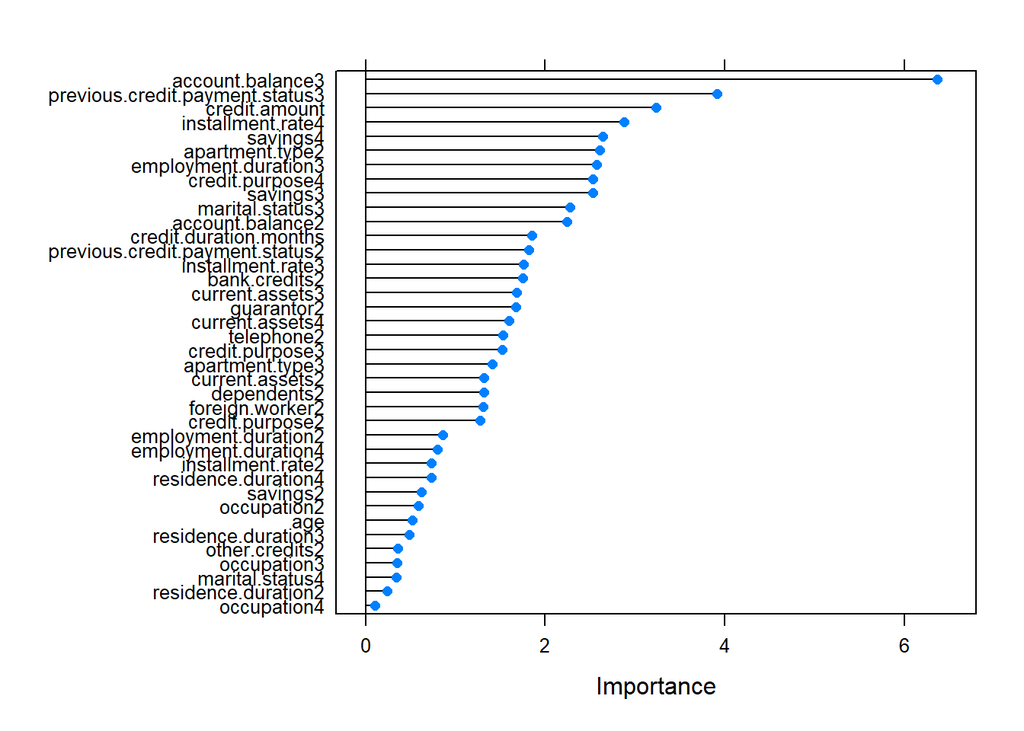

```r
formula<- "credit.rating ~ ."

formula<-as.formula(formula)

control<-trainControl(method = "repeatedcv", number = 10, repeats = 2)

model<- train(formula, data=train, method="glm",trControl=control)

importance<- varImp(model,scale = FALSE)

plot(importance)
```

### LOGESTIC REGRESSION MODEL WITH FEATURE SELECTION

```r
lr.model.new<- glm(formula= credit.rating~account.balance+credit.purpose+previous.credit.payment.status+savings+credit.duration.months, data=train,family = "binomial")

lr.predictions.new <- predict(lr.model.new, test.data, type="response")
lr.predictions.new <- round(lr.predictions.new)
u= union(lr.predictions.new,test.class.var)
confusionMatrix(table(factor(lr.predictions.new, u),
                      factor(test.class.var, u)))
```

```
## Confusion Matrix and Statistics
##
##
##       1   0
##   1 192  54
##   0  18  36
##
##                Accuracy : 0.76
##                  95% CI : (0.708, 0.807)
##     No Information Rate : 0.7
##     P-Value [Acc > NIR] : 0.0125
##
##                   Kappa : 0.355
##
##  Mcnemar's Test P-Value : 0.0000371
##
##             Sensitivity : 0.914
##             Specificity : 0.400
##          Pos Pred Value : 0.780
##          Neg Pred Value : 0.667
##              Prevalence : 0.700
##          Detection Rate : 0.640
##    Detection Prevalence : 0.820
##       Balanced Accuracy : 0.657
##
##        'Positive' Class : 1
##
```

### ROC CURVE

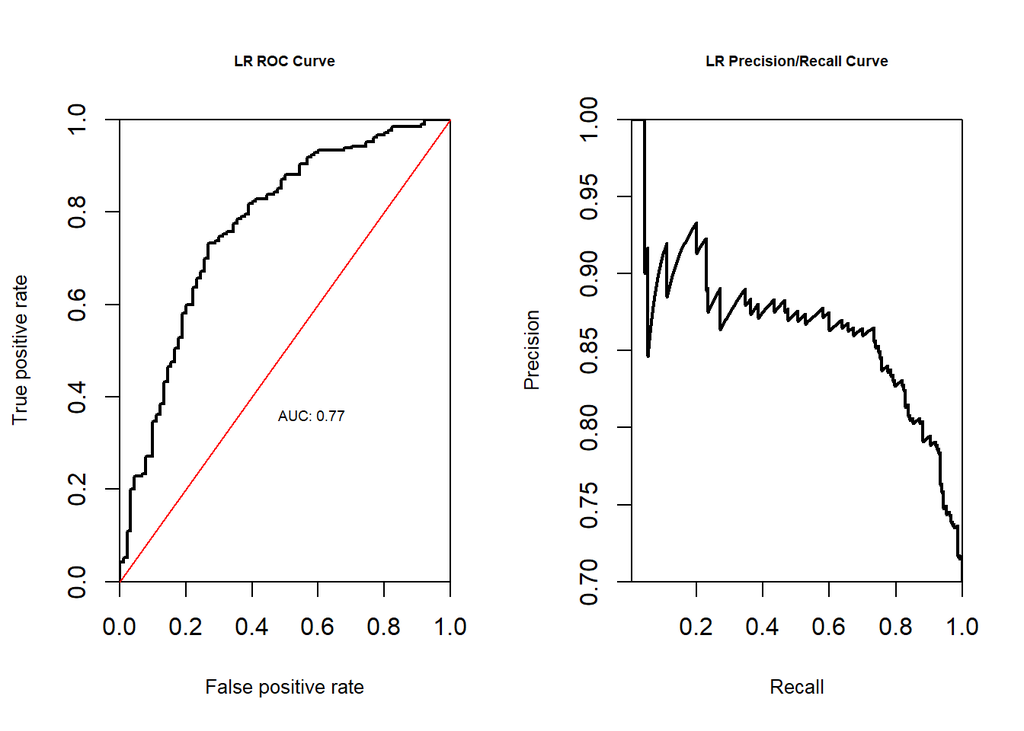

```r
lr.model.best <- lr.model


lr.prediction.values <- predict(lr.model.best, test.feature.vars,
                                type="response")

predictions <- prediction(lr.prediction.values, test.class.var)

par(mfrow=c(1,2))

plot.roc.curve(predictions, title.text="LR ROC Curve")

plot.pr.curve(predictions, title.text="LR Precision/Recall Curve")
```

```r
auc<- performance(predictions,"auc")
auc<- unlist(slot(auc,"y.values"))
auc<- round(auc,4)
auc
```

```
## [1] 0.77
```

### SUPPORT VECTOR MACHINE

```r
library(e1071) # svm model
library(caret) # model training\optimizations
library(kernlab) # svm model for hyperparameters
```

```r
library(ROCR) # model evaluation
source("performance_plot_utils.R") # plot model metrics

test.feature.vars<- test.data[,-1]

test.class.var<- test.data[,1]

## build initial model with training data
formula.init <- "credit.rating ~ ."
formula.init <- as.formula(formula.init)

svm.model<- svm(formula= formula.init, data = train,
                kernel="radial", cost=100, gamma=1)

summary(svm.model)
```

```
##
## Call:
## svm(formula = formula.init, data = train, kernel = "radial", cost = 100,
##     gamma = 1)
##
##
## Parameters:
##    SVM-Type:  C-classification
##  SVM-Kernel:  radial
##        cost:  100
##
## Number of Support Vectors:  700
##
##  ( 490 210 )
##
##
## Number of Classes:  2
##
## Levels:
##  0 1
```

```r
svm.predictions<- predict(svm.model, test.feature.vars)

u= union(svm.predictions,test.class.var)
confusionMatrix(table(factor(svm.predictions, u),
                      factor(test.class.var, u)))
```

```
## Confusion Matrix and Statistics
##
##
##       1   0
##   1 210  90
##   0   0   0
##
##                Accuracy : 0.7
##                  95% CI : (0.645, 0.751)
##     No Information Rate : 0.7
##     P-Value [Acc > NIR] : 0.528
##
##                   Kappa : 0
##
##  Mcnemar's Test P-Value : <0.0000000000000002
##
##             Sensitivity : 1.0
##             Specificity : 0.0
##          Pos Pred Value : 0.7
##          Neg Pred Value : NaN
##              Prevalence : 0.7
##          Detection Rate : 0.7
##    Detection Prevalence : 1.0
##       Balanced Accuracy : 0.5
##
##        'Positive' Class : 1
##
```

### FEATURE SELECTION

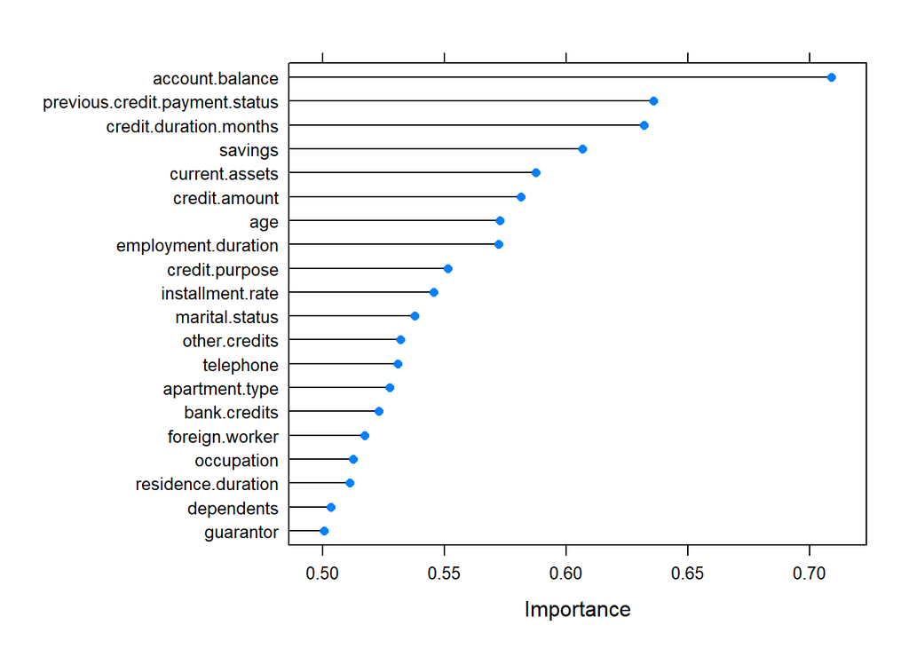

```r
formula.init <- "credit.rating ~ ."
formula.init <- as.formula(formula.init)
control <- trainControl(method="repeatedcv", number=10, repeats=2)
model <- train(formula.init, data=train, method="svmRadial",
               trControl=control)
importance <- varImp(model, scale=FALSE)
plot(importance, cex.lab=0.5)
```

### SVM WITH FEATURE SELECTION

```r
## build new model with selected features
formula.new <- "credit.rating ~ account.balance +
credit.duration.months +savings +
previous.credit.payment.status +credit.amount"
formula.new <- as.formula(formula.new)
svm.model.new <- svm(formula=formula.new, data=train,
                     kernel="radial", cost=10, gamma=0.25)

## predict results with new model on test data and
##evaluate new model performance
svm.predictions.new <- predict(svm.model.new, test.feature.vars)
u= union(svm.predictions.new,test.class.var)
confusionMatrix(table(factor(svm.predictions.new, u),
                      factor(test.class.var, u)))
```

```
## Confusion Matrix and Statistics
##
##
##       1   0
##   1 189  53
##   0  21  37
##
##                Accuracy : 0.753
##                  95% CI : (0.701, 0.801)
##     No Information Rate : 0.7
##     P-Value [Acc > NIR] : 0.023885
##
##                   Kappa : 0.346
##
##  Mcnemar's Test P-Value : 0.000314
##
##             Sensitivity : 0.900
##             Specificity : 0.411
##          Pos Pred Value : 0.781
##          Neg Pred Value : 0.638
##              Prevalence : 0.700
##          Detection Rate : 0.630
##    Detection Prevalence : 0.807
##       Balanced Accuracy : 0.656
##
##        'Positive' Class : 1
##
```

### DECISION TREE

```r
library(rpart)# tree models
library(caret) # feature selection
library(rpart.plot) # plot dtree
library(ROCR) # model evaluation
library(e1071) # tuning model
source("performance_plot_utils.R") # plotting curves

## separate feature and class variables
test.feature.vars <- test.data[,-1]
test.class.var <- test.data[,1]

formula.init <- "credit.rating ~ ."
formula.init <- as.formula(formula.init)
dt.model <- rpart(formula=formula.init, method="class",data=train,
                  control = rpart.control(minsplit=20, cp=0.05))

dt.predictions <- predict(dt.model, test.feature.vars, type="class")
u= union(dt.predictions,test.class.var)
confusionMatrix(table(factor(dt.predictions, u),
                      factor(test.class.var, u)))
```

```
## Confusion Matrix and Statistics
##
##
##       1   0
##   1 203  79
##   0   7  11
##
##                Accuracy : 0.713
##                  95% CI : (0.659, 0.764)
##     No Information Rate : 0.7
##     P-Value [Acc > NIR] : 0.332
##
##                   Kappa : 0.115
##
##  Mcnemar's Test P-Value : 0.0000000000000192
##
##             Sensitivity : 0.967
##             Specificity : 0.122
##          Pos Pred Value : 0.720
##          Neg Pred Value : 0.611
##              Prevalence : 0.700
##          Detection Rate : 0.677
##    Detection Prevalence : 0.940
##       Balanced Accuracy : 0.544
##
##        'Positive' Class : 1
##
```

### ROC CURVE

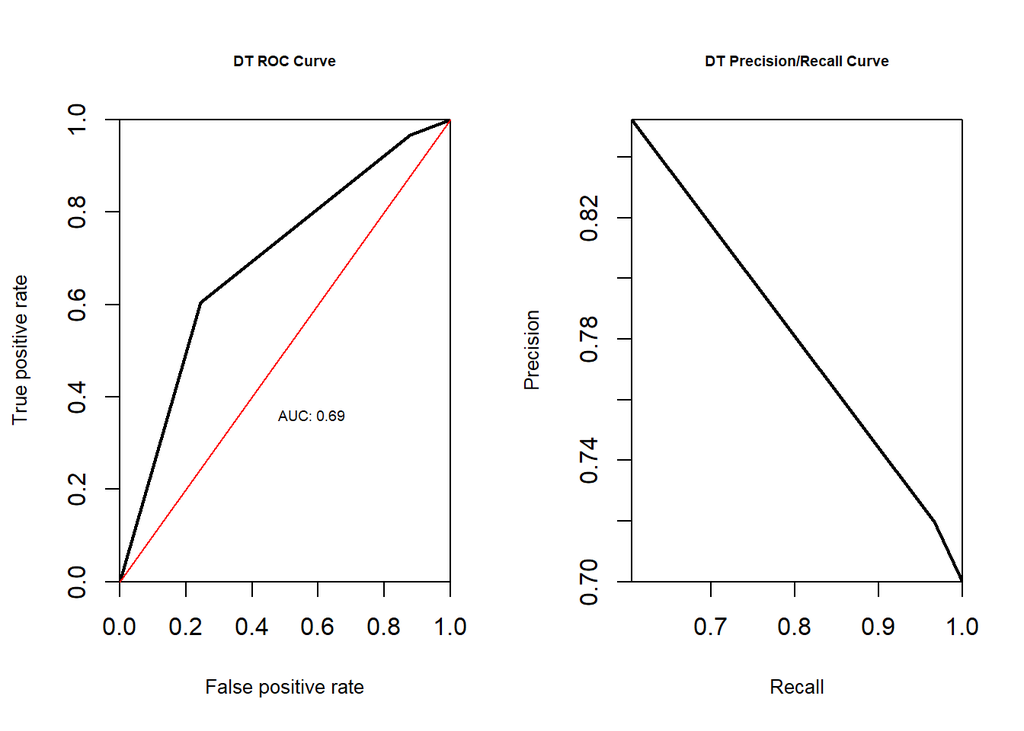

```r
dt.model.best <- dt.model
dt.predictions.best <- predict(dt.model.best, test.feature.vars,
                               type="prob")
dt.prediction.values <- dt.predictions.best[,2]
predictions <- prediction(dt.prediction.values, test.class.var)
par(mfrow=c(1,2))
plot.roc.curve(predictions, title.text="DT ROC Curve")
plot.pr.curve(predictions, title.text="DT Precision/Recall Curve")
```

```r
auc<- performance(predictions,"auc")
auc<- unlist(slot(auc,"y.values"))
auc<- round(auc,4)
auc
```

```
## [1] 0.69
```

### RANDOM FOREST

```r
library(randomForest) #rf model
library(caret) # feature selection
library(e1071) # model tuning
library(ROCR) # model evaluation
source("performance_plot_utils.R") # plot curves

indexes<-sample(1:nrow(credit.df),size= 0.6*nrow(credit.df))
test.data<- credit.df[-indexes,]

test.feature.vars <- test.data[,-1]
test.class.var <- test.data[,1]

formula.init <- "credit.rating ~ ."
formula.init <- as.formula(formula.init)
rf.model <- randomForest(formula.init, data = train,
                         importance=T, proximity=T)

print(rf.model)
```

```
##
## Call:
##  randomForest(formula = formula.init, data = train, importance = T,      proximity = T)
##                Type of random forest: classification
##                      Number of trees: 500
## No. of variables tried at each split: 4
##
##         OOB estimate of  error rate: 25%
## Confusion matrix:
##    0   1 class.error
## 0 86 124        0.59
## 1 49 441        0.10
```

```r
rf.predictions <- predict(rf.model, test.feature.vars, type="class")
u= union(rf.predictions,test.class.var)
confusionMatrix(table(factor(rf.predictions, u),
                      factor(test.class.var, u)))
```

```
## Confusion Matrix and Statistics
##
##
##       1   0
##   1 274  22
##   0   8  96
##
##                Accuracy : 0.925
##                  95% CI : (0.895, 0.949)
##     No Information Rate : 0.705
##     P-Value [Acc > NIR] : <0.0000000000000002
##
##                   Kappa : 0.813
##
##  Mcnemar's Test P-Value : 0.0176
##
##             Sensitivity : 0.972
##             Specificity : 0.814
##          Pos Pred Value : 0.926
##          Neg Pred Value : 0.923
##              Prevalence : 0.705
##          Detection Rate : 0.685
##    Detection Prevalence : 0.740
##       Balanced Accuracy : 0.893
##
##        'Positive' Class : 1
##
```

### ROC CURVE FOR RANDOM FOREST

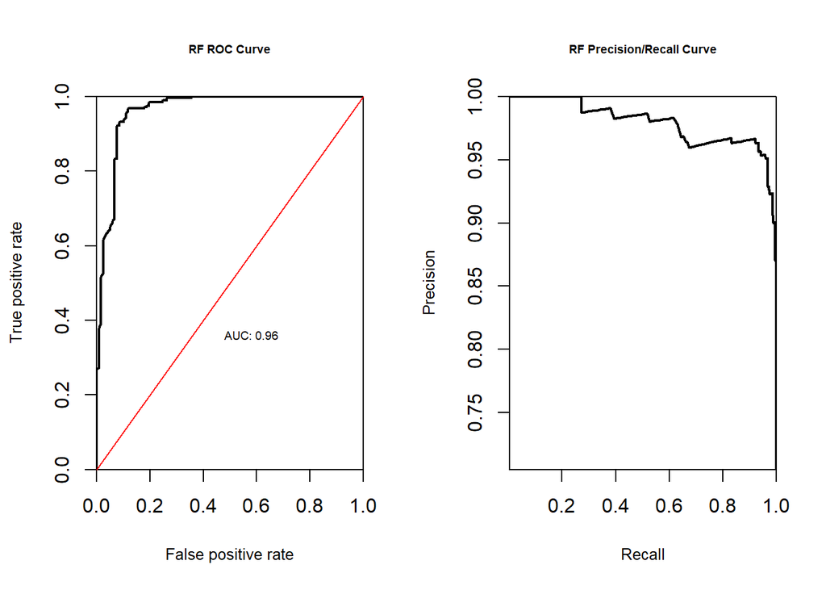

```r
rf.predictions.best <- predict(rf.model, test.feature.vars,
                               type="prob")
rf.prediction.values <- rf.predictions.best[,2]
predictions <- prediction(rf.prediction.values, test.class.var)
par(mfrow=c(1,2))
plot.roc.curve(predictions, title.text="RF ROC Curve")
plot.pr.curve(predictions, title.text="RF Precision/Recall Curve")
```

```r
auc<- performance(predictions,"auc")
auc<- unlist(slot(auc,"y.values"))
auc<- round(auc,4)
auc
```

```
## [1] 0.96
```

### Neural Network

```r
library(caret) # nn models
library(ROCR) # evaluate models
source("performance_plot_utils.R") # plot curves

test.feature.vars <- test.data[,-1]
test.class.var <- test.data[,1]

# data transformation
transformed.train <- train
transformed.test <- test.data
for (variable in categorical.vars){
  new.train.var <- make.names(train[[variable]])
  transformed.train[[variable]] <- new.train.var
  new.test.var <- make.names(test.data[[variable]])
  transformed.test[[variable]] <- new.test.var
}
transformed.train <- to.factors(df=transformed.train, variables=categorical.vars)
transformed.test <- to.factors(df=transformed.test, variables=categorical.vars)
transformed.test.feature.vars <- transformed.test[,-1]
transformed.test.class.var <- transformed.test[,1]

formula.init <- "credit.rating ~ ."
formula.init <- as.formula(formula.init)
nn.model <- train(formula.init, data = transformed.train,
                  method="nnet")
nn.predictions <- predict(nn.model, transformed.test.feature.vars,
                          type="raw")
u= union(nn.predictions, transformed.test.class.var)
confusionMatrix(table(factor(nn.predictions, u),
                      factor(transformed.test.class.var, u)))
```

```
## Confusion Matrix and Statistics
##
##
##       X0  X1
##   X0  65  23
##   X1  53 259
##
##                Accuracy : 0.81
##                  95% CI : (0.768, 0.847)
##     No Information Rate : 0.705
##     P-Value [Acc > NIR] : 0.00000109
##
##                   Kappa : 0.507
##
##  Mcnemar's Test P-Value : 0.000879
##
##             Sensitivity : 0.551
##             Specificity : 0.918
##          Pos Pred Value : 0.739
##          Neg Pred Value : 0.830
##              Prevalence : 0.295
##          Detection Rate : 0.163
##    Detection Prevalence : 0.220
##       Balanced Accuracy : 0.735
##
##        'Positive' Class : X0
##
```

### ROC CURVE

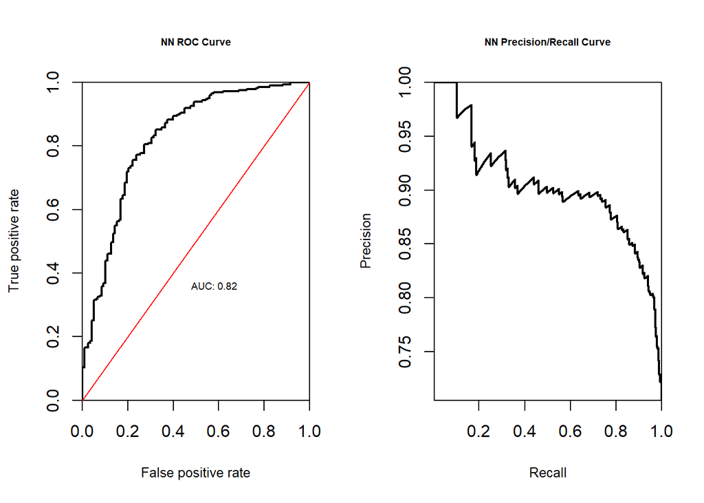

```r
nn.model.best <- nn.model
nn.predictions.best <-predict(nn.model.best,transformed.test.feature.vars,
                               type="prob")
nn.prediction.values <- nn.predictions.best[,2]
predictions <- prediction(nn.prediction.values, test.class.var)
par(mfrow=c(1,2))
plot.roc.curve(predictions, title.text="NN ROC Curve")
plot.pr.curve(predictions, title.text="NN Precision/Recall Curve")
```

```r
auc<- performance(predictions,"auc")
auc<- unlist(slot(auc,"y.values"))
auc<- round(auc,4)
auc
```

```
## [1] 0.82
```

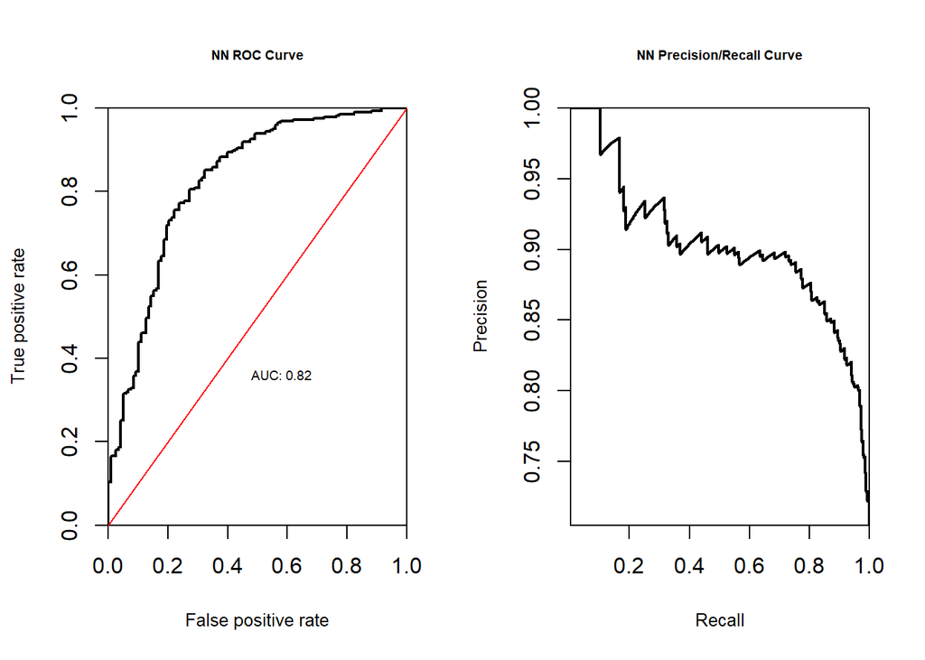

```r
nn.model.best <- nn.model
nn.predictions.best <-predict(nn.model.best,transformed.test.feature.vars,
                               type="prob")
nn.prediction.values <- nn.predictions.best[,2]
predictions <- prediction(nn.prediction.values, test.class.var)
par(mfrow=c(1,2))
plot.roc.curve(predictions, title.text="NN ROC Curve")
plot.pr.curve(predictions, title.text="NN Precision/Recall Curve")
```

```r
auc<- performance(predictions,"auc")
auc<- unlist(slot(auc,"y.values"))
auc<- round(auc,4)
auc
```

```
## [1] 0.82
```